# Previsão - Produtividade Sejud 2º grau

Diretoria de Execução de Expedientes

02 outubro, 2026

[figure not shown]

# 1 **Resumo**

Este estudo aborda a previsão dos indicadores de processos da Secretaria Judiciária de Segundo Grau do Tribunal de Justiça do Ceará (TJCE), incluindo os casos Baixados, Julgados e Novos. Para isso, utiliza-se o modelo de séries temporais SARIMA (Seasonal Autoregressive Integrated Moving Average) ou em português (Média Móvel Integrada Autoregressiva Sazonal), uma ferramenta que ajuda a prever quantidades futuras com base em padrões históricos. O SARIMA analisa os dados passados desses indicadores, considerando tanto tendências quanto sazonalidades, para fazer projeções precisas sobre a quantidade de processos para cada mês subsequente.

# 2 **Procedimentos Metodológicos**

Os procedimentos metodológicos adotados neste estudo foram cruciais para realizar a previsão mensal dos indicadores de processos da Secretaria Judiciária de Segundo Grau do Tribunal de Justiça do Ceará (TJCE). Inicialmente, foram coletados os dados históricos referentes aos casos Baixados, Julgados e Novos desde 2017, organizados em séries temporais mensais.

Após a coleta dos dados, foi utilizada a função “auto.arima” do software R, que automaticamente seleciona o modelo mais adequado para a previsão com base nos dados fornecidos. Essa abordagem permitiu uma análise eficiente e rápida, resultando na seleção do modelo ajustado para cada indicador de processo.

Com os modelos ajustados, foram geradas previsões mensais para os indicadores de processos. Essas previsões vêem sendo então comparadas com os valores reais para avaliar a precisão do modelo e sua capacidade de prever os indicadores com base nos dados históricos.

# 3 **Base de dados**

**Pacotes utilizados**

```r
require(openxlsx)
require(readxl)
library(DT)
require(tseries)
require(xts)
require(forecast)
```

**Encontrar o diretório do(s) arquivo(s) de dados**

```r
getwd()
```

```
## [1] "C:/Users/nilto/Desktop/MATERIAL TJ/3. ANÁLISE DE SÉRIES TEMPORAIS"
```

**Informar ao R onde se encontra o(s) arquivo(s) de dados**

```r
setwd("C:/Users/nilto/Desktop/MATERIAL TJ/3. ANÁLISE DE SÉRIES TEMPORAIS")
```

**Importar a(s) bases de dados**

```r
Produtividade_2017 <- read_excel("C:/Users/nilto/Desktop/MATERIAL TJ/3. ANÁLISE DE SÉRIES TEMPORAIS/Produtividade_2017.xlsx")

Produtividade_2018_a_Atual_Atualizar_ <- read_excel("C:/Users/nilto/Desktop/MATERIAL TJ/3. ANÁLISE DE SÉRIES TEMPORAIS/Produtividade_2018_a_Atual(Atualizar).xlsx")
```

**Juntar as bases de dados**

```r
Produtividade <- rbind(Produtividade_2017,Produtividade_2018_a_Atual_Atualizar_)
```

**Tabela final dos dados utilizados para o estudo das previsões**

```r
datatable(Produtividade,
          editable="cell",
          caption = "Produtividade - NEXE",
          extensions = "Buttons",
          filter='top',
          options=list(papeLength=10,
                       searching=TRUE,
                       dom='Blfrtip',
                       buttons=c(I('colvis'),'copy','csv','excel','pdf','print'),
                       columnDefs = list(list(visible=FALSE,targets = c(7:ncol(Produtividade))))))
```

|  | DATA | ANO | Nome do mês | N. Mês | COMPETÊNCIA | INDICADOR | Quantidade |
| --- | --- | --- | --- | --- | --- | --- | --- |
| 1 | 2017-01-01T00:00:00Z | 2017 | JANEIRO | 1 | Órgão Especial | Novos | 59 |
| 2 | 2017-01-01T00:00:00Z | 2017 | JANEIRO | 1 | Demais | Julgados | 1 |
| 3 | 2017-01-01T00:00:00Z | 2017 | JANEIRO | 1 | Câmara Criminal | Baixados | 295 |
| 4 | 2017-01-01T00:00:00Z | 2017 | JANEIRO | 1 | Câmara de Direito Público | Novos | 722 |
| 5 | 2017-01-01T00:00:00Z | 2017 | JANEIRO | 1 | Câmara de Direito Privado | Baixados | 363 |
| 6 | 2017-01-01T00:00:00Z | 2017 | JANEIRO | 1 | Demais | Julgados | 33 |
| 7 | 2017-01-01T00:00:00Z | 2017 | JANEIRO | 1 | Câmara Criminal | Julgados | 239 |
| 8 | 2017-01-01T00:00:00Z | 2017 | JANEIRO | 1 | Demais | Baixados | 84 |
| 9 | 2017-01-01T00:00:00Z | 2017 | JANEIRO | 1 | Câmara de Direito Público | Julgados | 447 |
| 10 | 2017-01-01T00:00:00Z | 2017 | JANEIRO | 1 | Órgão Especial | Julgados | 51 |

[output cut: 28880 more lines]

# 4 **Previsão de Processos Baixados**

## 4.1 Todas as Competências

**Série Temporal (Todas as Competências)**

```r
BAIXADOS=Produtividade[(Produtividade$"INDICADOR" == "Baixados"),]
BAIXADOS=aggregate(cbind(BAIXADOS$Quantidade)~BAIXADOS$`N. Mês` + BAIXADOS$ANO,data=BAIXADOS,sum)
BAIXADOS_mensal=data.frame(BAIXADOS)
BAIXADOS_mensal=data.frame(BAIXADOS_mensal[,3])
BAIXADOS_mensal_st=ts(BAIXADOS_mensal, start=c(2017,1),frequency = 12);BAIXADOS_mensal_st
```

```
##        Jan   Feb   Mar   Apr   May   Jun   Jul   Aug   Sep   Oct   Nov   Dec
## 2017  1165  2655  3009  1748  3677  2792  2471  2740  2260  2098  2199  1507
## 2018   817  2237  1985  3202  3193  3472  2769  3602  2850  3339  3242  2764
## 2019  1554  3198  2666  3302  3366  3114  3054  3890  3264  5309  3774  3066
## 2020  3111  3885  3671  1668  1251  3255  4950  5708  5269  5935  5599  3138
## 2021  3658  4437  5346  5668  6240  6278  6282  6283  5392  5225  5631  3367
## 2022  2944  5257  6606  5156  6444  5278  5827  5209  4556  5418  5357  5044
## 2023  2223  3940  7070  6117  8591  7115  5302  6784  5733  6327  6768  4476
## 2024  4013  7051  6876  7641  7373  7703  8955  8274  7923  9509  8547  6437
## 2025  3278  9305  8093  9737  9430  8516  9126  6806 10000  9521  9416  9212
## 2026  3234  9670 11286  9634  9610 12438 11336 10721 11262
```

**Modelo ajustado (Todas as Competências)**

```r
fit_BAIXADOS_mensal = auto.arima(BAIXADOS_mensal_st)
fit_BAIXADOS_mensal = fit_BAIXADOS_mensal %>% forecast (h=1, level=95)
fit_BAIXADOS_mensal
```

```
##          Point Forecast    Lo 95    Hi 95
## Oct 2026       10232.92 7911.097 12554.74
```

**Estimativa pontual da quantidade de Baixas (Todas as Competências)**

```r
BAIXADOS_mensal_media=round(fit_BAIXADOS_mensal$mean,0);BAIXADOS_mensal_media
```

```
##        Oct
## 2026 10233
```

**Limite Inferior do intervalo de confiança da quantidade de Baixas (Todas as Competências)**

```r
BAIXADOS_mensal_inferior=round(fit_BAIXADOS_mensal$lower,0);BAIXADOS_mensal_inferior
```

```
##       Oct
## 2026 7911
```

**Limite Superior do intervalo de confiança da quantidade de Baixas (Todas as Competências)**

```r
BAIXADOS_mensal_superior=round(fit_BAIXADOS_mensal$upper,0);BAIXADOS_mensal_superior
```

```
##        Oct
## 2026 12555
```

**Gráfico da série temporal com a estimativa pontual e intervalo de confiança com 95% de confiança (Todas as Competências)**

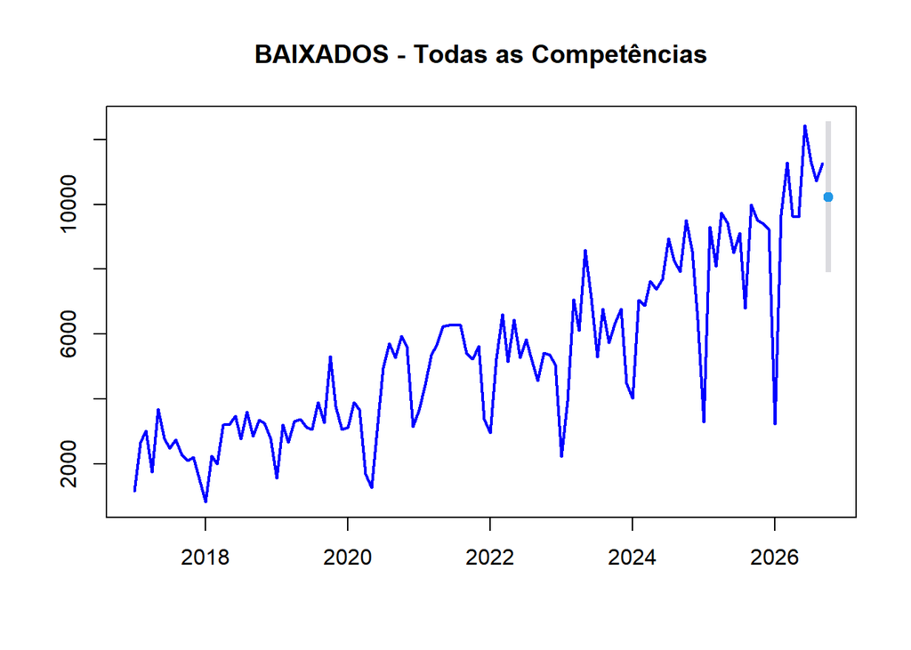

```r
fit_BAIXADOS_mensal %>% forecast (h=1, level=95) %>% plot(main="BAIXADOS - Todas as Competências",col="blue",lwd=2)
```

## 4.2 Câmara de Direito Privado

**Série Temporal (Câmara de Direito Privado)**

```r
BAIXADOS=Produtividade[(Produtividade$"INDICADOR" == "Baixados"),]
BAIXADOS_Camara_DP=BAIXADOS[(BAIXADOS$COMPETÊNCIA == "Câmara de Direito Privado"),]
BAIXADOS_Camara_DP=aggregate(cbind(BAIXADOS_Camara_DP$Quantidade)~BAIXADOS_Camara_DP$`N. Mês` + BAIXADOS_Camara_DP$ANO,data=BAIXADOS_Camara_DP,sum)
BAIXADOS_Camara_DP_mensal=data.frame(BAIXADOS_Camara_DP)
BAIXADOS_Camara_DP_mensal=data.frame(BAIXADOS_Camara_DP_mensal[,3])
BAIXADOS_Camara_DP_mensal_st=ts(BAIXADOS_Camara_DP_mensal, start=c(2017,1),frequency = 12);BAIXADOS_Camara_DP_mensal_st
```

```
##       Jan  Feb  Mar  Apr  May  Jun  Jul  Aug  Sep  Oct  Nov  Dec
## 2017  363 1017 1164  623 1451 1166 1177 1047  937  739  850  428
## 2018  401  799  757 1057 1092 1140 1133 1414  890 1035 1593  745
## 2019  702 1119  790  945  996  869  726 1562 1307 2170 1874 1106
## 2020 1678 1859 1511  443  513 1472 2531 2023 1835 2302 2282  975
## 2021 1865 1995 1912 2132 1730 1886 2320 2042 2124 2263 2298 1490
## 2022 1093 2393 2491 2108 2444 1830 2357 1712 1874 2084 1921 1909
## 2023  749 1556 2624 2991 4564 3261 2531 3528 2920 3269 3957 2169
## 2024 1890 4081 3148 3907 4170 3691 5025 4427 4310 4618 4941 3222
## 2025 1405 4974 4013 5331 5099 4525 4867 3622 5561 4552 4829 4993
## 2026 1641 5467 5325 4983 5414 6553 6422 5446 6513
```

**Modelo ajustado (Câmara de Direito Privado)**

```r
fit_BAIXADOS_Camara_DP_mensal = auto.arima(BAIXADOS_Camara_DP_mensal_st)
fit_BAIXADOS_Camara_DP_mensal=fit_BAIXADOS_Camara_DP_mensal %>% forecast (h=1, level=95)
fit_BAIXADOS_Camara_DP_mensal
```

```
##          Point Forecast    Lo 95    Hi 95
## Oct 2026       5465.091 4259.953 6670.229
```

**Estimativa pontual da quantidade de Baixas (Câmara de Direito Privado)**

```r
BAIXADOS_Camara_DP_media=round(fit_BAIXADOS_Camara_DP_mensal$mean,0)
BAIXADOS_Camara_DP_media
```

```
##       Oct
## 2026 5465
```

**Limite Inferior do intervalo de confiança da quantidade de Baixas (Câmara de Direito Privado)**

```r
BAIXADOS_Camara_DP_inferior=round(fit_BAIXADOS_Camara_DP_mensal$lower,0)
BAIXADOS_Camara_DP_inferior
```

```
##       Oct
## 2026 4260
```

**Limite Superior do intervalo de confiança da quantidade de Baixas (Câmara de Direito Privado)**

```r
BAIXADOS_Camara_DP_superior=round(fit_BAIXADOS_Camara_DP_mensal$upper,0)
BAIXADOS_Camara_DP_superior
```

```
##       Oct
## 2026 6670
```

**Gráfico da série temporal com a estimativa pontual e intervalo de confiança com 95% de confiança (Câmara de Direito Privado)**

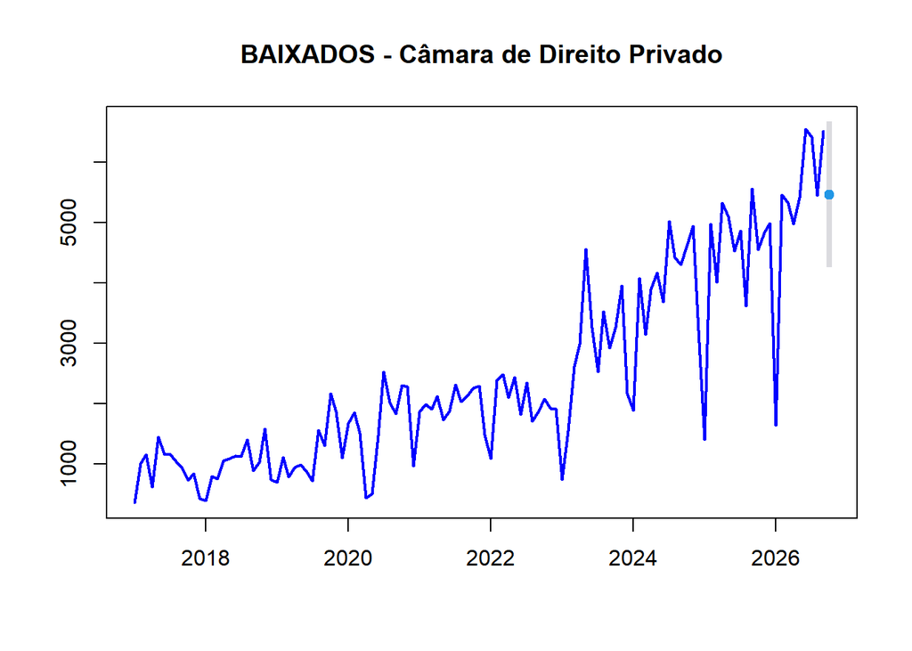

```r
fit_BAIXADOS_Camara_DP_mensal %>% forecast (h=1, level=95) %>% plot(main="BAIXADOS - Câmara de Direito Privado",col="blue",lwd=2)
```

## 4.3 Câmara de Direito Público

**Série Temporal (Câmara de Direito Público)**

```r
BAIXADOS=Produtividade[(Produtividade$"INDICADOR" == "Baixados"),]
BAIXADOS_Camara_DPU=BAIXADOS[(BAIXADOS$COMPETÊNCIA == "Câmara de Direito Público"),]
BAIXADOS_Camara_DPU=aggregate(cbind(BAIXADOS_Camara_DPU$Quantidade)~BAIXADOS_Camara_DPU$`N. Mês` + BAIXADOS_Camara_DPU$ANO,data=BAIXADOS_Camara_DPU,sum)
BAIXADOS_Camara_DPU_mensal=data.frame(BAIXADOS_Camara_DPU)
BAIXADOS_Camara_DPU_mensal=data.frame(BAIXADOS_Camara_DPU_mensal[,3])
BAIXADOS_Camara_DPU_mensal_st=ts(BAIXADOS_Camara_DPU_mensal, start=c(2017,1),frequency = 12);BAIXADOS_Camara_DPU_mensal_st
```

```
##       Jan  Feb  Mar  Apr  May  Jun  Jul  Aug  Sep  Oct  Nov  Dec
## 2017  409  509  863  521  864  354  304  373  217  356  232  227
## 2018  181  300  244  387  348  749  377  729  410  753  588  441
## 2019  490  713  542  880 1057  975  768 1011  699 1206  985  629
## 2020  933  789  679  856  320  487 1097 1636 1258 1356 1186  840
## 2021  926 1264 1600 1480 2068 1902 1765 1885 1421 1142 1382  827
## 2022  822 1293 1750 1374 1961 1590 1521 1996 1313 1530 2006 1908
## 2023  642 1106 2472 1675 2072 1763 1370 1607 1265 1292 1206  917
## 2024  932 1113 1774 1676 1339 1754 1647 1784 1660 2626 1978 1644
## 2025  948 2021 2151 1704 1813 1947 2038 1380 2107 2016 1691 1768
## 2026  551 1437 2679 1700 1943 2494 1767 2534 1899
```

**Modelo ajustado (Câmara de Direito Público)**

```r
fit_BAIXADOS_Camara_DPU_mensal = auto.arima(BAIXADOS_Camara_DPU_mensal_st)
fit_BAIXADOS_Camara_DPU_mensal=fit_BAIXADOS_Camara_DPU_mensal %>% forecast (h=1, level=95)
fit_BAIXADOS_Camara_DPU_mensal
```

```
##          Point Forecast    Lo 95    Hi 95
## Oct 2026       2405.538 1707.858 3103.217
```

**Estimativa pontual da quantidade de Baixas (Câmara de Direito Público)**

```r
BAIXADOS_Camara_DPU_media=round(fit_BAIXADOS_Camara_DPU_mensal$mean,0)
BAIXADOS_Camara_DPU_media
```

```
##       Oct
## 2026 2406
```

**Limite Inferior do intervalo de confiança da quantidade de Baixas (Câmara de Direito Público)**

```r
BAIXADOS_Camara_DPU_inferior=round(fit_BAIXADOS_Camara_DPU_mensal$lower,0)
BAIXADOS_Camara_DPU_inferior
```

```
##       Oct
## 2026 1708
```

**Limite Superior do intervalo de confiança da quantidade de Baixas (Câmara de Direito Público)**

```r
BAIXADOS_Camara_DPU_superior=round(fit_BAIXADOS_Camara_DPU_mensal$upper,0)
BAIXADOS_Camara_DPU_superior
```

```
##       Oct
## 2026 3103
```

**Gráfico da série temporal com a estimativa pontual e intervalo de confiança com 95% de confiança (Câmara de Direito Público)**

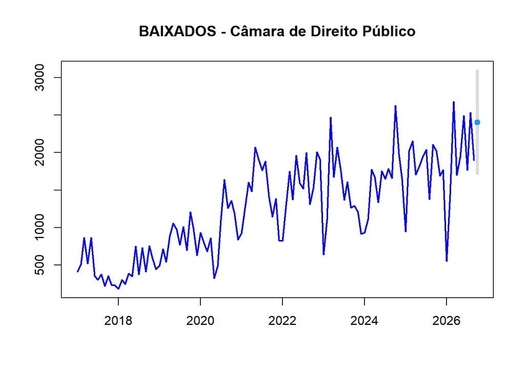

```r
fit_BAIXADOS_Camara_DPU_mensal %>% forecast (h=1, level=95) %>% plot(main="BAIXADOS - Câmara de Direito Público",col="blue",lwd=2)
```

## 4.4 Órgão Especial

**Série Temporal (Órgão Especial)**

```r
BAIXADOS=Produtividade[(Produtividade$"INDICADOR" == "Baixados"),]
BAIXADOS_Orgao_Especial=BAIXADOS[(BAIXADOS$COMPETÊNCIA == "Órgão Especial"),]
BAIXADOS_Orgao_Especial=aggregate(cbind(BAIXADOS_Orgao_Especial$Quantidade)~BAIXADOS_Orgao_Especial$`N. Mês` + BAIXADOS_Orgao_Especial$ANO,data=BAIXADOS_Orgao_Especial,sum)
BAIXADOS_Orgao_Especial_mensal=data.frame(BAIXADOS_Orgao_Especial)
BAIXADOS_Orgao_Especial_mensal=data.frame(BAIXADOS_Orgao_Especial_mensal[,3])
BAIXADOS_Orgao_Especial_mensal_st=ts(BAIXADOS_Orgao_Especial_mensal, start=c(2017,1),frequency = 12);BAIXADOS_Orgao_Especial_mensal_st
```

```
##      Jan Feb Mar Apr May Jun Jul Aug Sep Oct Nov Dec
## 2017  14  42  85  43  28  41  44  48  39  36  32  21
## 2018   9  52  42  77  86  55  48 125  64  80  47  18
## 2019  21  39  26  80  61  43  69  46  27 100  72  37
## 2020  15  72  33  45  10  38  67  72  47 122  60  28
## 2021  17  92 144 141 243 119  92  99  99  59  81  18
## 2022  39  88  85 118  89 210  93  74  78  54  89  40
## 2023  58  65  51  28  45  57  48  70  56  50  79  60
## 2024  24 114  89 114  88  90 119  64  52  86  62  40
## 2025  24  64 107  87 157  75 104  85 101 103 140 114
## 2026  58  79 197 135 141 141 167 113 218
```

**Modelo ajustado (Órgão Especial)**

```r
fit_BAIXADOS_Orgao_Especial_mensal = auto.arima(BAIXADOS_Orgao_Especial_mensal_st)
fit_BAIXADOS_Orgao_Especial_mensal=fit_BAIXADOS_Orgao_Especial_mensal %>% forecast (h=1, level=95)
fit_BAIXADOS_Orgao_Especial_mensal
```

```
##          Point Forecast    Lo 95    Hi 95
## Oct 2026       166.6184 93.92666 239.3102
```

**Estimativa pontual da quantidade de Baixas (Órgão Especial)**

```r
BAIXADOS_Orgao_Especial_media=round(fit_BAIXADOS_Orgao_Especial_mensal$mean,0)
BAIXADOS_Orgao_Especial_media
```

```
##      Oct
## 2026 167
```

**Limite Inferior do intervalo de confiança da quantidade de Baixas (Órgão Especial)**

```r
BAIXADOS_Orgao_Especial_inferior=round(fit_BAIXADOS_Orgao_Especial_mensal$lower,0)
BAIXADOS_Orgao_Especial_inferior
```

```
##      Oct
## 2026  94
```

**Limite Superior do intervalo de confiança da quantidade de Baixas (Órgão Especial)**

```r
BAIXADOS_Orgao_Especial_superior=round(fit_BAIXADOS_Orgao_Especial_mensal$upper,0)
BAIXADOS_Orgao_Especial_superior
```

```
##      Oct
## 2026 239
```

**Gráfico da série temporal com a estimativa pontual e intervalo de confiança com 95% de confiança (Órgão Especial)**

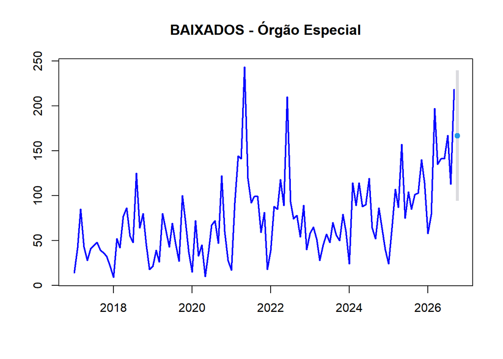

```r
fit_BAIXADOS_Orgao_Especial_mensal %>% forecast (h=1, level=95) %>% plot(main="BAIXADOS - Órgão Especial",col="blue",lwd=2)
```

## 4.5 Câmara Criminal

**Série Temporal (Câmara Criminal)**

```r
BAIXADOS=Produtividade[(Produtividade$"INDICADOR" == "Baixados"),]
BAIXADOS_Camara_Criminal=BAIXADOS[(BAIXADOS$COMPETÊNCIA == "Câmara Criminal"),]
BAIXADOS_Camara_Criminal=aggregate(cbind(BAIXADOS_Camara_Criminal$Quantidade)~BAIXADOS_Camara_Criminal$`N. Mês` + BAIXADOS_Camara_Criminal$ANO,data=BAIXADOS_Camara_Criminal,sum)
BAIXADOS_Camara_Criminal_mensal=data.frame(BAIXADOS_Camara_Criminal)
BAIXADOS_Camara_Criminal_mensal=data.frame(BAIXADOS_Camara_Criminal_mensal[,3])
BAIXADOS_Camara_Criminal_mensal_st=ts(BAIXADOS_Camara_Criminal_mensal, start=c(2017,1),frequency = 12);BAIXADOS_Camara_Criminal_mensal_st
```

```
##       Jan  Feb  Mar  Apr  May  Jun  Jul  Aug  Sep  Oct  Nov  Dec
## 2017  295  934  726  373 1223  827  783 1119  881  819  959  612
## 2018   73  856  646 1282 1161 1122  838  930 1129 1209  873 1464
## 2019  297 1248 1264 1313 1199 1176 1405 1188 1209 1690  791 1189
## 2020  481 1121 1409  312  404 1244 1156 1923 2062 2089 1989 1269
## 2021  824 1018 1656 1884 2121 2333 2043 2197 1702 1705 1833 1019
## 2022  960 1445 2240 1532 1892 1519 1789 1387 1250 1699 1274 1157
## 2023  763 1174 1880 1399 1867 1998 1284 1539 1426 1673 1444 1278
## 2024 1094 1633 1787 1826 1746 2042 2034 1943 1767 2089 1473 1453
## 2025  867 2154 1703 2495 2202 1871 1993 1529 1918 2217 2120 1752
## 2026  680 2114 2576 2328 1407 2624 2378 1848 1933
```

**Modelo ajustado (Câmara Criminal)**

```r
fit_BAIXADOS_Camara_Criminal_mensal = auto.arima(BAIXADOS_Camara_Criminal_mensal_st)
fit_BAIXADOS_Camara_Criminal_mensal=fit_BAIXADOS_Camara_Criminal_mensal %>% forecast (h=1, level=95)
fit_BAIXADOS_Camara_Criminal_mensal
```

```
##          Point Forecast    Lo 95    Hi 95
## Oct 2026       2105.901 1349.126 2862.677
```

**Estimativa pontual da quantidade de Baixas (Câmara Criminal)**

```r
BAIXADOS_Camara_Criminal_media=round(fit_BAIXADOS_Camara_Criminal_mensal$mean,0)
BAIXADOS_Camara_Criminal_media
```

```
##       Oct
## 2026 2106
```

**Limite Inferior do intervalo de confiança da quantidade de Baixas (Câmara Criminal)**

```r
BAIXADOS_Camara_Criminal_inferior=round(fit_BAIXADOS_Camara_Criminal_mensal$lower,0)
BAIXADOS_Camara_Criminal_inferior
```

```
##       Oct
## 2026 1349
```

**Limite Superior do intervalo de confiança da quantidade de Baixas (Câmara Criminal)**

```r
BAIXADOS_Camara_Criminal_superior=round(fit_BAIXADOS_Camara_Criminal_mensal$upper,0)
BAIXADOS_Camara_Criminal_superior
```

```
##       Oct
## 2026 2863
```

**Gráfico da série temporal com a estimativa pontual e intervalo de confiança com 95% de confiança (Câmara Criminal)**

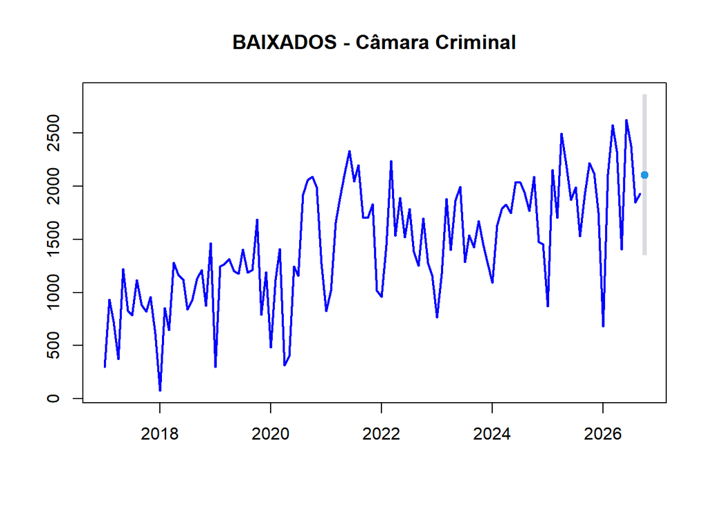

```r
fit_BAIXADOS_Camara_Criminal_mensal %>% forecast (h=1, level=95) %>% plot(main="BAIXADOS - Câmara Criminal",col="blue",lwd=2)
```

## 4.6 Demais Competências

**Série Temporal (Demais Competências)**

```r
BAIXADOS_Demais=Produtividade[(Produtividade$"INDICADOR" == "Baixados" & Produtividade$"COMPETÊNCIA" == "Demais"),]
BAIXADOS_Demais=aggregate(cbind(BAIXADOS_Demais$Quantidade)~BAIXADOS_Demais$`N. Mês` + BAIXADOS_Demais$ANO,data=BAIXADOS_Demais,sum)
BAIXADOS_Demais=data.frame(BAIXADOS_Demais)
BAIXADOS_Demais=data.frame(BAIXADOS_Demais[,3])
BAIXADOS_Demais_st=ts(BAIXADOS_Demais, start=c(2017,1),frequency = 12);BAIXADOS_Demais_st
```

```
##      Jan Feb Mar Apr May Jun Jul Aug Sep Oct Nov Dec
## 2017  84 153 171 188 111 404 163 153 186 148 126 219
## 2018 153 230 296 399 506 406 373 404 357 262 141  96
## 2019  44  79  44  84  53  51  86  83  22 143  52 105
## 2020   4  44  39  12   4  14  99  54  67  66  82  26
## 2021  26  68  34  31  78  38  62  60  46  56  37  13
## 2022  30  38  40  24  58 129  67  40  41  51  67  30
## 2023  11  39  43  24  43  36  69  40  66  43  82  52
## 2024  73 110  78 118  30 126 130  56 134  90  93  78
## 2025  34  92 119 120 159  98 124 190 313 633 636 585
## 2026 304 573 509 488 705 626 602 780 699
```

**Modelo ajustado (Demais Competências)**

```r
fit_BAIXADOS_Demais = auto.arima(BAIXADOS_Demais_st)
fit_BAIXADOS_Demais=fit_BAIXADOS_Demais %>% forecast (h=1, level=95)
fit_BAIXADOS_Demais
```

```
##          Point Forecast    Lo 95    Hi 95
## Oct 2026       708.2967 556.0236 860.5698
```

**Estimativa pontual da quantidade de Baixas (Demais Competências)**

```r
BAIXADOS_Demais_media=round(fit_BAIXADOS_Demais$mean,0)
BAIXADOS_Demais_media
```

```
##      Oct
## 2026 708
```

**Limite Inferior do intervalo de confiança da quantidade de Baixas (Demais Competências)**

```r
BAIXADOS_Demais_inferior=round(fit_BAIXADOS_Demais$lower,0)
BAIXADOS_Demais_inferior
```

```
##      Oct
## 2026 556
```

**Limite Superior do intervalo de confiança da quantidade de Baixas (Demais Competências)**

```r
BAIXADOS_Demais_superior=round(fit_BAIXADOS_Demais$upper,0)
BAIXADOS_Demais_superior
```

```
##      Oct
## 2026 861
```

**Gráfico da série temporal com a estimativa pontual e intervalo de confiança com 95% de confiança (Demais Competências)**

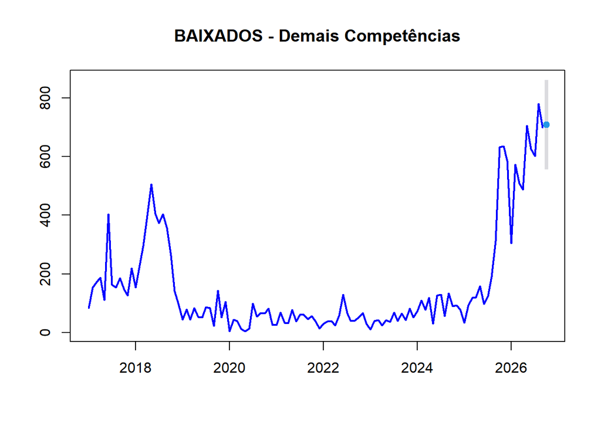

```r
fit_BAIXADOS_Demais %>% forecast (h=1, level=95) %>% plot(main="BAIXADOS - Demais Competências",col="blue",lwd=2)
```

## 4.7 Tabela de Previsões

```r
Todos=c(BAIXADOS_mensal_media,
BAIXADOS_mensal_inferior,
BAIXADOS_mensal_superior)

Câmara_de_Direito_Privado=c(BAIXADOS_Camara_DP_media,
BAIXADOS_Camara_DP_inferior,
BAIXADOS_Camara_DP_superior)

Câmara_de_Direito_Público=c(BAIXADOS_Camara_DPU_media,
BAIXADOS_Camara_DPU_inferior,
BAIXADOS_Camara_DPU_superior)

Órgão_Especial=c(BAIXADOS_Orgao_Especial_media,
BAIXADOS_Orgao_Especial_inferior,
BAIXADOS_Orgao_Especial_superior)

Câmara_Criminal=c(BAIXADOS_Camara_Criminal_media,
BAIXADOS_Camara_Criminal_inferior,
BAIXADOS_Camara_Criminal_superior)

Demais=c(BAIXADOS_Demais_media,
BAIXADOS_Demais_inferior,
BAIXADOS_Demais_superior)


Baixados=rbind(Todos,Câmara_de_Direito_Privado,Câmara_de_Direito_Público,Órgão_Especial,Câmara_Criminal,Demais)
colnames(Baixados) = c("Previsão","Limite Inferior","Limite Superior")
Baixados=data.frame(Baixados)
Baixados
```

```
##                           Previsão Limite.Inferior Limite.Superior
## Todos                        10233            7911           12555
## Câmara_de_Direito_Privado     5465            4260            6670
## Câmara_de_Direito_Público     2406            1708            3103
## Órgão_Especial                 167              94             239
## Câmara_Criminal               2106            1349            2863
## Demais                         708             556             861
```

```r
datatable(Baixados,
          editable="cell",
          caption = "Previsões de Baixas com intervalo de confiança preditivo de 95% de confiabilidade",
          extensions = "Buttons",
          filter='top',
          options=list(papeLength=10,
                       searching=TRUE,
                       dom='Blfrtip',
                       buttons=c('copy','csv','excel','pdf','print')))
```

|  | Previsão | Limite.Inferior | Limite.Superior |
| --- | --- | --- | --- |
| Todos | 10233 | 7911 | 12555 |
| Câmara_de_Direito_Privado | 5465 | 4260 | 6670 |
| Câmara_de_Direito_Público | 2406 | 1708 | 3103 |
| Órgão_Especial | 167 | 94 | 239 |
| Câmara_Criminal | 2106 | 1349 | 2863 |
| Demais | 708 | 556 | 861 |

# 5 **Previsão de Processos Julgados**

## 5.1 Todas as Competências

**Série Temporal (Todas as Competências)**

```r
JULGADOS=Produtividade[(Produtividade$"INDICADOR" == "Julgados"),]
JULGADOS=aggregate(cbind(JULGADOS$Quantidade)~JULGADOS$`N. Mês` + JULGADOS$ANO,data=JULGADOS,sum)
JULGADOS_mensal=data.frame(JULGADOS)
JULGADOS_mensal=data.frame(JULGADOS_mensal[,3])
JULGADOS_mensal_st=ts(JULGADOS_mensal, start=c(2017,1),frequency = 12);JULGADOS_mensal_st
```

```
##        Jan   Feb   Mar   Apr   May   Jun   Jul   Aug   Sep   Oct   Nov   Dec
## 2017  1363  2583  3229  2398  2648  2813  2147  2813  2293  2682  2255  2222
## 2018  1093  2008  2414  2292  2643  3411  2936  3335  2733  3592  3481  2724
## 2019  1877  3309  2529  3809  3361  3389  4397  3981  3700  5321  4045  3907
## 2020  2440  3733  3594  4737  5485  6400  4404  4564  5431  4951  4983  4636
## 2021  2209  5656  6367  4985  5075  5699  4682  5875  5036  5441  4981  3928
## 2022  2403  5843  6598  4496  5915  6472  6055  6927  5696  6138  7467  4376
## 2023  2932  5805  7145  5656  7600  6117  5777  6845  5721  7509  6780  5670
## 2024  3949  7298  6400  8451  8704  9003 10115  9060  9874 10913  8112  7262
## 2025  4811  9745  7524 10542  8555 10201 10628  9216 11964 11444 13180 10695
## 2026  5295 11334 13225 13067 12701 14768 13087 13114 13951
```

**Modelo ajustado (Todas as Competências)**

```r
fit_JULGADOS_mensal = auto.arima(JULGADOS_mensal_st)
fit_JULGADOS_mensal = fit_JULGADOS_mensal %>% forecast (h=1, level=95)
fit_JULGADOS_mensal
```

```
##          Point Forecast    Lo 95    Hi 95
## Oct 2026       14470.92 12429.76 16512.08
```

**Estimativa pontual da quantidade de Julgados (Todas as Competências)**

```r
JULGADOS_mensal_media=round(fit_JULGADOS_mensal$mean,0)
JULGADOS_mensal_media
```

```
##        Oct
## 2026 14471
```

**Limite Inferior do intervalo de confiança da quantidade de Julgados (Todas as Competências)**

```r
JULGADOS_mensal_inferior=round(fit_JULGADOS_mensal$lower,0)
JULGADOS_mensal_inferior
```

```
##        Oct
## 2026 12430
```

**Limite Superior do intervalo de confiança da quantidade de Julgados (Todas as Competências)**

```r
JULGADOS_mensal_superior=round(fit_JULGADOS_mensal$upper,0)
JULGADOS_mensal_superior
```

```
##        Oct
## 2026 16512
```

**Gráfico da série temporal com a estimativa pontual e intervalo de confiança com 95% de confiança (Todas as Competências)**

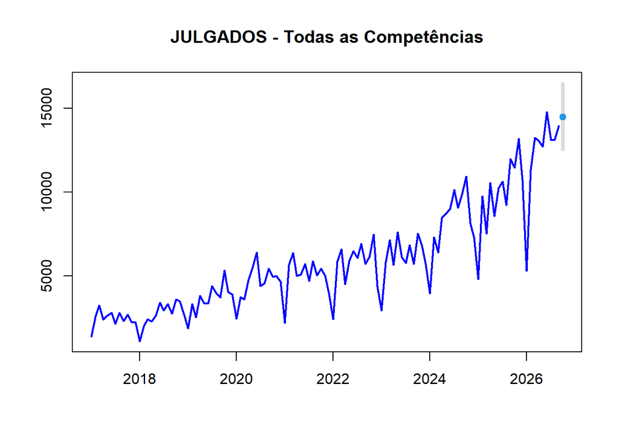

```r
fit_JULGADOS_mensal %>% forecast (h=1, level=95) %>% plot(main="JULGADOS - Todas as Competências",col="blue",lwd=2)
```

## 5.2 Câmara de Direito Privado

**Série Temporal (Câmara de Direito Privado)**

```r
JULGADOS=Produtividade[(Produtividade$"INDICADOR" == "Julgados"),]
JULGADOS_Camara_DP=JULGADOS[(JULGADOS$COMPETÊNCIA == "Câmara de Direito Privado"),]
JULGADOS_Camara_DP=aggregate(cbind(JULGADOS_Camara_DP$Quantidade)~JULGADOS_Camara_DP$`N. Mês` + JULGADOS_Camara_DP$ANO,data=JULGADOS_Camara_DP,sum)
JULGADOS_Camara_DP_mensal=data.frame(JULGADOS_Camara_DP)
JULGADOS_Camara_DP_mensal=data.frame(JULGADOS_Camara_DP_mensal[,3])
JULGADOS_Camara_DP_mensal_st=ts(JULGADOS_Camara_DP_mensal, start=c(2017,1),frequency = 12);JULGADOS_Camara_DP_mensal_st
```

```
##       Jan  Feb  Mar  Apr  May  Jun  Jul  Aug  Sep  Oct  Nov  Dec
## 2017  589 1038 1293 1184 1091 1225  958 1261  858 1026  834  813
## 2018  471  765  927  797 1212 1565 1071 1299 1026 1435 1532  894
## 2019  737 1129  908 1391 1301 1382 1648 1734 1673 2343 1663 1342
## 2020 1136 1635 1546 1770 2373 2573 1638 1777 2073 2010 2044 1670
## 2021 1031 2174 2489 1993 1976 2086 1671 2375 2184 2323 1920 1547
## 2022 1015 2447 2685 1782 2137 2644 2722 2649 2113 2377 2931 1611
## 2023 1407 2320 3458 2590 3541 3212 2875 3761 3046 3640 3507 2779
## 2024 2150 3790 3372 4062 4393 4560 4676 4734 5056 5844 4122 3533
## 2025 2411 5120 4024 5579 4364 5055 5887 5098 6233 6481 7178 5854
## 2026 3254 6191 6992 7491 7482 8168 7650 7593 8256
```

**Modelo ajustado (Câmara de Direito Privado)**

```r
fit_JULGADOS_Camara_DP_mensal = auto.arima(JULGADOS_Camara_DP_mensal_st)
fit_JULGADOS_Camara_DP_mensal = fit_JULGADOS_Camara_DP_mensal %>% forecast (h=1, level=95)
fit_JULGADOS_Camara_DP_mensal
```

```
##          Point Forecast    Lo 95    Hi 95
## Oct 2026       8625.715 7580.595 9670.835
```

**Estimativa pontual da quantidade de Julgados (Câmara de Direito Privado)**

```r
JULGADOS_Camara_DP_media=round(fit_JULGADOS_Camara_DP_mensal$mean,0)
JULGADOS_Camara_DP_media
```

```
##       Oct
## 2026 8626
```

**Limite Inferior do intervalo de confiança da quantidade de Julgados (Câmara de Direito Privado)**

```r
JULGADOS_Camara_DP_inferior=round(fit_JULGADOS_Camara_DP_mensal$lower,0)
JULGADOS_Camara_DP_inferior
```

```
##       Oct
## 2026 7581
```

**Limite Superior do intervalo de confiança da quantidade de Julgados (Câmara de Direito Privado)**

```r
JULGADOS_Camara_DP_superior=round(fit_JULGADOS_Camara_DP_mensal$upper,0)
JULGADOS_Camara_DP_superior
```

```
##       Oct
## 2026 9671
```

**Gráfico da série temporal com a estimativa pontual e intervalo de confiança com 95% de confiança (Câmara de Direito Privado)**

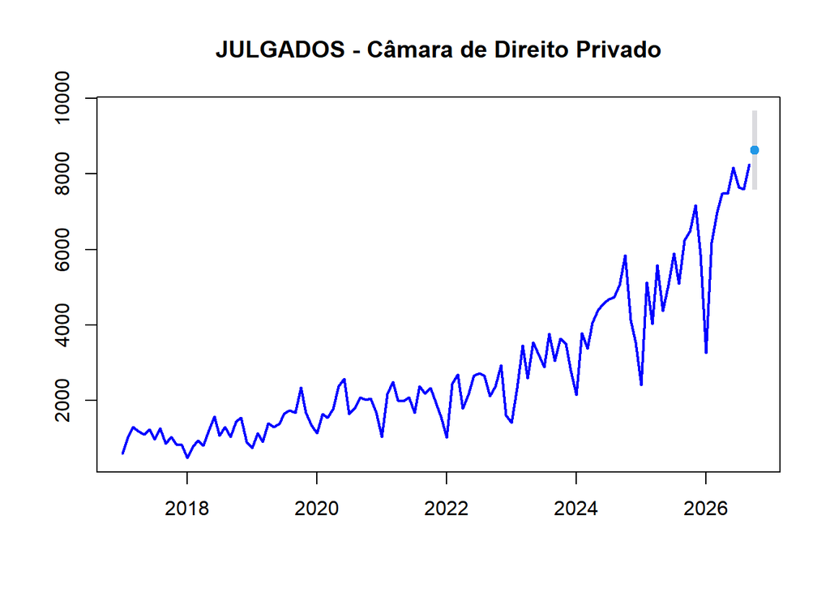

```r
fit_JULGADOS_Camara_DP_mensal %>% forecast (h=1, level=95) %>% plot(main="JULGADOS - Câmara de Direito Privado",col="blue",lwd=2)
```

## 5.3 Câmara de Direito Público

**Série Temporal (Câmara de Direito Público)**

```r
JULGADOS=Produtividade[(Produtividade$"INDICADOR" == "Julgados"),]
JULGADOS_Camara_DPU=JULGADOS[(JULGADOS$COMPETÊNCIA == "Câmara de Direito Público"),]
JULGADOS_Camara_DPU=aggregate(cbind(JULGADOS_Camara_DPU$Quantidade)~JULGADOS_Camara_DPU$`N. Mês` + JULGADOS_Camara_DPU$ANO,data=JULGADOS_Camara_DPU,sum)
JULGADOS_Camara_DPU_mensal=data.frame(JULGADOS_Camara_DPU)
JULGADOS_Camara_DPU_mensal=data.frame(JULGADOS_Camara_DPU_mensal[,3])
JULGADOS_Camara_DPU_mensal_st=ts(JULGADOS_Camara_DPU_mensal, start=c(2017,1),frequency = 12);JULGADOS_Camara_DPU_mensal_st
```

```
##       Jan  Feb  Mar  Apr  May  Jun  Jul  Aug  Sep  Oct  Nov  Dec
## 2017  447  734  861  545  712  620  507  464  602  682  642  511
## 2018  164  450  494  537  628  774  668  801  645  815  854  788
## 2019  512  843  602 1051  815  863 1022 1068  921 1269 1043 1018
## 2020  481  923 1008 1345 1363 1549  995 1158 1392 1341 1545 1097
## 2021  579 1350 1507 1273 1671 1634 1305 1536 1441 1750 1320  982
## 2022  826 1595 1708 1250 2168 2061 1683 2322 2112 2183 2451 1204
## 2023  831 1729 1776 1389 1851 1339 1331 1239 1057 1719 1458 1149
## 2024  826 1584 1508 2383 2379 2451 3082 2289 2755 2471 2355 1784
## 2025 1145 2376 1753 2524 2212 2972 2512 1572 2653 2255 2535 2508
## 2026  854 2327 2768 2498 2445 3246 2507 2824 2982
```

**Modelo ajustado (Câmara de Direito Público)**

```r
fit_JULGADOS_Camara_DPU_mensal = auto.arima(JULGADOS_Camara_DPU_mensal_st)
fit_JULGADOS_Camara_DPU_mensal = fit_JULGADOS_Camara_DPU_mensal %>% forecast (h=1, level=95)
fit_JULGADOS_Camara_DPU_mensal
```

```
##          Point Forecast    Lo 95    Hi 95
## Oct 2026       2557.415 1926.048 3188.783
```

**Estimativa pontual da quantidade de Julgados (Câmara de Direito Público)**

```r
JULGADOS_Camara_DPU_media=round(fit_JULGADOS_Camara_DPU_mensal$mean,0)
JULGADOS_Camara_DPU_media
```

```
##       Oct
## 2026 2557
```

**Limite Inferior do intervalo de confiança da quantidade de Julgados (Câmara de Direito Público)**

```r
JULGADOS_Camara_DPU_inferior=round(fit_JULGADOS_Camara_DPU_mensal$lower,0)
JULGADOS_Camara_DPU_inferior
```

```
##       Oct
## 2026 1926
```

**Limite Superior do intervalo de confiança da quantidade de Julgados (Câmara de Direito Público)**

```r
JULGADOS_Camara_DPU_superior=round(fit_JULGADOS_Camara_DPU_mensal$upper,0)
JULGADOS_Camara_DPU_superior
```

```
##       Oct
## 2026 3189
```

**Gráfico da série temporal com a estimativa pontual e intervalo de confiança com 95% de confiança (Câmara de Direito Público)**

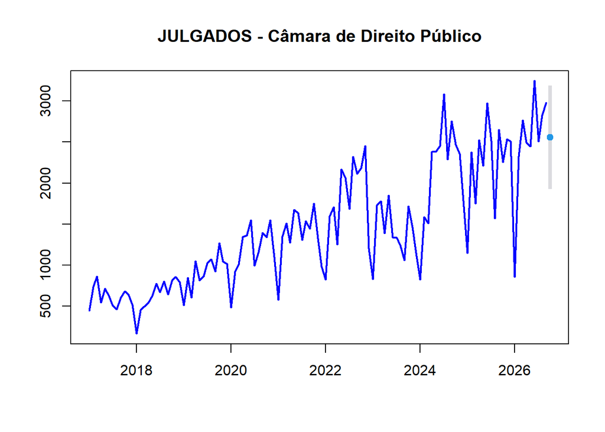

```r
fit_JULGADOS_Camara_DPU_mensal %>% forecast (h=1, level=95) %>% plot(main="JULGADOS - Câmara de Direito Público",col="blue",lwd=2)
```

## 5.4 Órgão Especial

**Série Temporal (Órgão Especial)**

```r
JULGADOS=Produtividade[(Produtividade$"INDICADOR" == "Julgados"),]
JULGADOS_Orgao_Especial=JULGADOS[(JULGADOS$COMPETÊNCIA == "Órgão Especial"),]
JULGADOS_Orgao_Especial=aggregate(cbind(JULGADOS_Orgao_Especial$Quantidade)~JULGADOS_Orgao_Especial$`N. Mês` + JULGADOS_Orgao_Especial$ANO,data=JULGADOS_Orgao_Especial,sum)
JULGADOS_Orgao_Especial_mensal=data.frame(JULGADOS_Orgao_Especial)
JULGADOS_Orgao_Especial_mensal=data.frame(JULGADOS_Orgao_Especial_mensal[,3])
JULGADOS_Orgao_Especial_mensal_st=ts(JULGADOS_Orgao_Especial_mensal, start=c(2017,1),frequency = 12);JULGADOS_Orgao_Especial_mensal_st
```

```
##      Jan Feb Mar Apr May Jun Jul Aug Sep Oct Nov Dec
## 2017  51  41  51  44  44  68  30  58  42  33  50  46
## 2018  70  44  72  82  47  90  54  59  58  80  61  61
## 2019  41  59  61  74  73  62  76  81  49  81  98  69
## 2020  44  71  76  60  65  65  47  64  82  83 120 152
## 2021 108 131 174 169  90  98  87  99  67  57  44  74
## 2022  78  97 134  95 101 104 139  87  80  54  76  50
## 2023  61  39  76  34  45  62  34  77  47  56  89  46
## 2024  24 104  78  83  85  88  72  54  64  99  60  61
## 2025  49  75  88  87 132  70 120 136 105 114 117 127
## 2026  53  58 130 126 194 159 238 155 160
```

**Modelo ajustado (Órgão Especial)**

```r
fit_JULGADOS_Orgao_Especial_mensal = auto.arima(JULGADOS_Orgao_Especial_mensal_st)
fit_JULGADOS_Orgao_Especial_mensal = fit_JULGADOS_Orgao_Especial_mensal %>% forecast (h=1, level=95)
fit_JULGADOS_Orgao_Especial_mensal
```

```
##          Point Forecast    Lo 95    Hi 95
## Oct 2026       167.4591 115.3265 219.5918
```

**Estimativa pontual da quantidade de Julgados (Órgão Especial)**

```r
JULGADOS_Orgao_Especial_media=round(fit_JULGADOS_Orgao_Especial_mensal$mean,0)
JULGADOS_Orgao_Especial_media
```

```
##      Oct
## 2026 167
```

**Limite Inferior do intervalo de confiança da quantidade de Julgados (Órgão Especial)**

```r
JULGADOS_Orgao_Especial_inferior=round(fit_JULGADOS_Orgao_Especial_mensal$lower,0)
JULGADOS_Orgao_Especial_inferior
```

```
##      Oct
## 2026 115
```

**Limite Superior do intervalo de confiança da quantidade de Julgados (Órgão Especial)**

```r
JULGADOS_Orgao_Especial_superior=round(fit_JULGADOS_Orgao_Especial_mensal$upper,0)
JULGADOS_Orgao_Especial_superior
```

```
##      Oct
## 2026 220
```

**Gráfico da série temporal com a estimativa pontual e intervalo de confiança com 95% de confiança (Órgão Especial)**

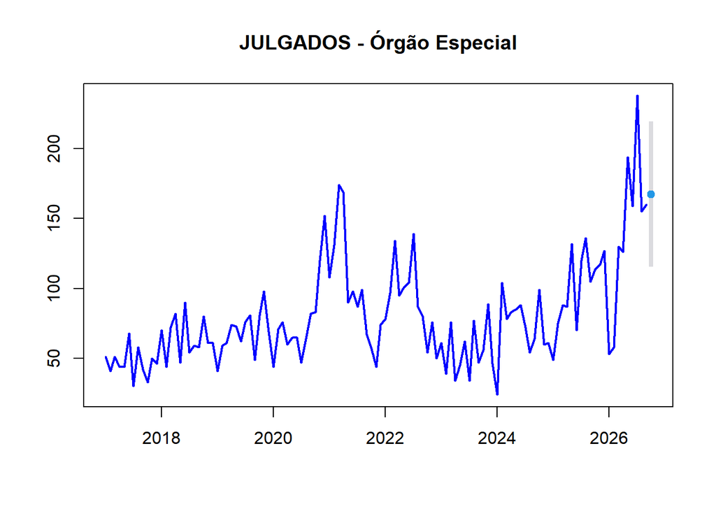

```r
fit_JULGADOS_Orgao_Especial_mensal %>% forecast (h=1, level=95) %>% plot(main="JULGADOS - Órgão Especial",col="blue",lwd=2)
```

## 5.5 Câmara Criminal

**Série Temporal (Câmara Criminal)**

```r
JULGADOS=Produtividade[(Produtividade$"INDICADOR" == "Julgados"),]
JULGADOS_Camara_Criminal=JULGADOS[(JULGADOS$COMPETÊNCIA == "Câmara Criminal"),]
JULGADOS_Camara_Criminal=aggregate(cbind(JULGADOS_Camara_Criminal$Quantidade)~JULGADOS_Camara_Criminal$`N. Mês` + JULGADOS_Camara_Criminal$ANO,data=JULGADOS_Camara_Criminal,sum)
JULGADOS_Camara_Criminal_mensal=data.frame(JULGADOS_Camara_Criminal)
JULGADOS_Camara_Criminal_mensal=data.frame(JULGADOS_Camara_Criminal_mensal[,3])
JULGADOS_Camara_Criminal_mensal_st=ts(JULGADOS_Camara_Criminal_mensal, start=c(2017,1),frequency = 12);JULGADOS_Camara_Criminal_mensal_st
```

```
##       Jan  Feb  Mar  Apr  May  Jun  Jul  Aug  Sep  Oct  Nov  Dec
## 2017  239  747  992  580  765  858  616 1005  770  890  685  800
## 2018  346  708  887  851  711  932 1115 1132  965 1240 1007  954
## 2019  569 1244  933 1267 1125 1063 1617 1064 1018 1599 1210 1453
## 2020  770 1083  931 1495 1647 2165 1692 1520 1852 1481 1242 1669
## 2021  484 1962 2140 1481 1294 1857 1590 1825 1299 1286 1658 1294
## 2022  460 1667 2029 1332 1471 1616 1458 1818 1349 1489 1981 1473
## 2023  610 1693 1805 1600 2084 1452 1474 1676 1550 1989 1643 1558
## 2024  885 1755 1373 1825 1747 1800 2191 1881 1869 2406 1492 1730
## 2025 1188 2050 1545 2239 1754 1924 1937 2028 2278 1904 2260 1686
## 2026  962 2289 2595 1980 2137 2503 1714 1747 2125
```

**Modelo ajustado (Câmara Criminal)**

```r
fit_JULGADOS_Camara_Criminal_mensal = auto.arima(JULGADOS_Camara_Criminal_mensal_st)
fit_JULGADOS_Camara_Criminal_mensal = fit_JULGADOS_Camara_Criminal_mensal %>% forecast (h=1, level=95)
fit_JULGADOS_Camara_Criminal_mensal
```

```
##          Point Forecast    Lo 95    Hi 95
## Oct 2026       2110.798 1518.872 2702.723
```

**Estimativa pontual da quantidade de Julgados (Câmara Criminal)**

```r
JULGADOS_Camara_Criminal_media=round(fit_JULGADOS_Camara_Criminal_mensal$mean,0)
JULGADOS_Camara_Criminal_media
```

```
##       Oct
## 2026 2111
```

**Limite Inferior do intervalo de confiança da quantidade de Julgados (Câmara Criminal)**

```r
JULGADOS_Camara_Criminal_inferior=round(fit_JULGADOS_Camara_Criminal_mensal$lower,0)
JULGADOS_Camara_Criminal_inferior
```

```
##       Oct
## 2026 1519
```

**Limite Superior do intervalo de confiança da quantidade de Julgados (Câmara Criminal)**

```r
JULGADOS_Camara_Criminal_superior=round(fit_JULGADOS_Camara_Criminal_mensal$upper,0)
JULGADOS_Camara_Criminal_superior
```

```
##       Oct
## 2026 2703
```

**Gráfico da série temporal com a estimativa pontual e intervalo de confiança com 95% de confiança (Câmara Criminal)**

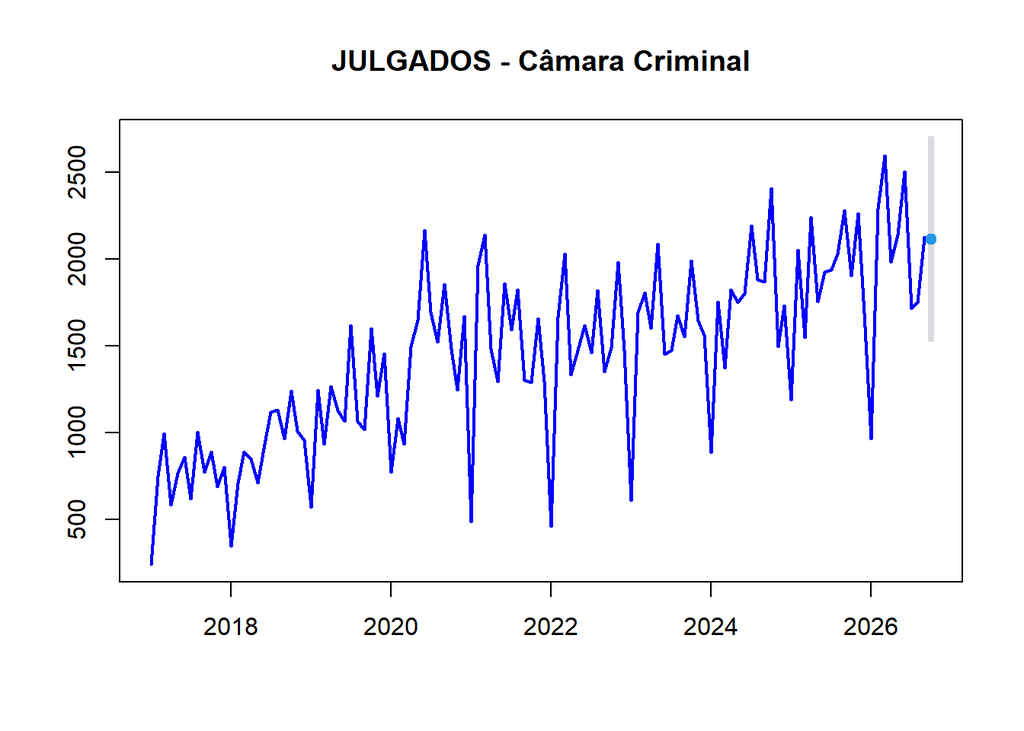

```r
fit_JULGADOS_Camara_Criminal_mensal %>% forecast (h=1, level=95) %>% plot(main="JULGADOS - Câmara Criminal",col="blue",lwd=2)
```

## 5.6 Demais Competências

**Série Temporal (Demais Competências)**

```r
JULGADOS_Demais=Produtividade[(Produtividade$"INDICADOR" == "Julgados" & Produtividade$"COMPETÊNCIA" == "Demais"),]
JULGADOS_Demais=aggregate(cbind(JULGADOS_Demais$Quantidade)~JULGADOS_Demais$`N. Mês` + JULGADOS_Demais$ANO,data=JULGADOS_Demais,sum)
JULGADOS_Demais=data.frame(JULGADOS_Demais)
JULGADOS_Demais=data.frame(JULGADOS_Demais[,3])
JULGADOS_Demais_st=ts(JULGADOS_Demais, start=c(2017,1),frequency = 12);JULGADOS_Demais_st
```

```
##       Jan  Feb  Mar  Apr  May  Jun  Jul  Aug  Sep  Oct  Nov  Dec
## 2017   37   23   32   45   36   42   36   25   21   51   44   52
## 2018   42   41   34   25   45   50   28   44   39   22   27   27
## 2019   18   34   25   26   47   19   34   34   39   29   31   25
## 2020    9   21   33   67   37   48   32   45   32   36   32   48
## 2021    7   39   57   69   44   24   29   40   45   25   39   31
## 2022   24   37   42   37   38   47   53   51   42   35   28   38
## 2023   23   24   30   43   79   52   63   92   21  105   83  138
## 2024   64   65   69   98  100  104   94  102  130   93   83  154
## 2025   18  124  114  113   93  180  172  382  695  690 1090  520
## 2026  172  469  740  972  443  692  978  795  428
```

**Modelo ajustado (Demais Competências)**

```r
fit_JULGADOS_Demais = auto.arima(JULGADOS_Demais_st)
fit_JULGADOS_Demais = fit_JULGADOS_Demais %>% forecast (h=1, level=95)
fit_JULGADOS_Demais
```

```
##          Point Forecast  Lo 95    Hi 95
## Oct 2026       519.6871 310.33 729.0441
```

**Estimativa pontual da quantidade de Julgados (Demais Competências)**

```r
JULGADOS_Demais_media=round(fit_JULGADOS_Demais$mean,0)
JULGADOS_Demais_media
```

```
##      Oct
## 2026 520
```

**Limite Inferior do intervalo de confiança da quantidade de Julgados (Demais Competências)**

```r
JULGADOS_Demais_inferior=round(fit_JULGADOS_Demais$lower,0)
JULGADOS_Demais_inferior
```

```
##      Oct
## 2026 310
```

**Limite Superior do intervalo de confiança da quantidade de Julgados (Demais Competências)**

```r
JULGADOS_Demais_superior=round(fit_JULGADOS_Demais$upper,0)
JULGADOS_Demais_superior
```

```
##      Oct
## 2026 729
```

**Gráfico da série temporal com a estimativa pontual e intervalo de confiança com 95% de confiança (Demais Competências)**

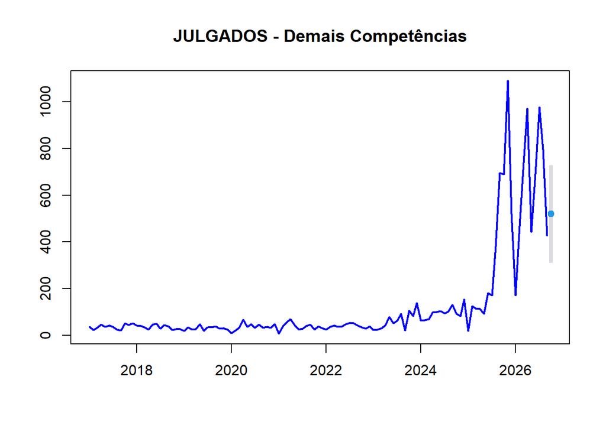

```r
fit_JULGADOS_Demais %>% forecast (h=1, level=95) %>% plot(main="JULGADOS - Demais Competências",col="blue",lwd=2)
```

## 5.7 Tabela de Previsões

```r
Todos=c(JULGADOS_mensal_media,
JULGADOS_mensal_inferior,
JULGADOS_mensal_superior)

Câmara_de_Direito_Privado=c(JULGADOS_Camara_DP_media,
JULGADOS_Camara_DP_inferior,
JULGADOS_Camara_DP_superior)

Câmara_de_Direito_Público=c(JULGADOS_Camara_DPU_media,
JULGADOS_Camara_DPU_inferior,
JULGADOS_Camara_DPU_superior)

Órgão_Especial=c(JULGADOS_Orgao_Especial_media,
JULGADOS_Orgao_Especial_inferior,
JULGADOS_Orgao_Especial_superior)

Câmara_Criminal=c(JULGADOS_Camara_Criminal_media,
JULGADOS_Camara_Criminal_inferior,
JULGADOS_Camara_Criminal_superior)

Demais=c(JULGADOS_Demais_media,
JULGADOS_Demais_inferior,
JULGADOS_Demais_superior)


Julgados=rbind(Todos,Câmara_de_Direito_Privado,Câmara_de_Direito_Público,Órgão_Especial,Câmara_Criminal,Demais)
colnames(Julgados) = c("Previsão","Limite Inferior","Limite Superior")
Julgados=data.frame(Julgados)
Julgados
```

```
##                           Previsão Limite.Inferior Limite.Superior
## Todos                        14471           12430           16512
## Câmara_de_Direito_Privado     8626            7581            9671
## Câmara_de_Direito_Público     2557            1926            3189
## Órgão_Especial                 167             115             220
## Câmara_Criminal               2111            1519            2703
## Demais                         520             310             729
```

```r
datatable(Julgados,
          editable="cell",
          caption = "Previsões de Julgados com intervalo de confiança preditivo de 95% de confiabilidade",
          extensions = "Buttons",
          filter='top',
          options=list(papeLength=10,
                       searching=TRUE,
                       dom='Blfrtip',
                       buttons=c('copy','csv','excel','pdf','print')))
```

|  | Previsão | Limite.Inferior | Limite.Superior |
| --- | --- | --- | --- |
| Todos | 14471 | 12430 | 16512 |
| Câmara_de_Direito_Privado | 8626 | 7581 | 9671 |
| Câmara_de_Direito_Público | 2557 | 1926 | 3189 |
| Órgão_Especial | 167 | 115 | 220 |
| Câmara_Criminal | 2111 | 1519 | 2703 |
| Demais | 520 | 310 | 729 |

# 6 **Previsão de Casos Novos**

## 6.1 Todas as Competências

**Série Temporal (Todas as Competências)**

```r
NOVOS=Produtividade[(Produtividade$"INDICADOR" == "Novos"),]
NOVOS=aggregate(cbind(NOVOS$Quantidade)~NOVOS$`N. Mês` + NOVOS$ANO,data=NOVOS,sum)
NOVOS_mensal=data.frame(NOVOS)
NOVOS_mensal=data.frame(NOVOS_mensal[,3])
NOVOS_mensal_st=ts(NOVOS_mensal, start=c(2017,1),frequency = 12);NOVOS_mensal_st
```

```
##        Jan   Feb   Mar   Apr   May   Jun   Jul   Aug   Sep   Oct   Nov   Dec
## 2017  2348  2269  3314  2743  2882  2294  2384  3107  3259  2615  2234  1551
## 2018  1878  2460  2571  4469  3573  3871  2161  2775  2759  2981  3284  2231
## 2019  2717  3415  2995  3663  4395  3695  3715  4620  4039  4487  5290  3451
## 2020  3907  3850  4409  4601  5305  5641  5353  5143  5400  5339  4762  3168
## 2021  4263  4629  5114  4817  5946  5720  4738  6169  5057  4750  4548  3011
## 2022  4181  6457  7166  5510  6132  5160  6222  6763  6661  5956  5716  3204
## 2023  4065  4911  6722  4703  6166  6194  5905  6919  6098  6199  5679  4150
## 2024  3977  5619  5734  7292  7166  7893  8185  7579  7654  8505  7681  6376
## 2025  5367  8218  7524  8354  9906  9451  9635  9256  9906 10308 10164  7170
## 2026  6824  9500 10684 10293 10645 10549 10727 10273 10556
```

**Modelo ajustado (Todas as Competências)**

```r
fit_NOVOS_mensal = auto.arima(NOVOS_mensal_st)
fit_NOVOS_mensal = fit_NOVOS_mensal %>% forecast (h=1, level=95)
fit_NOVOS_mensal
```

```
##          Point Forecast    Lo 95    Hi 95
## Oct 2026       11001.12 9559.298 12442.93
```

**Estimativa pontual da quantidade de Novos (Todas as Competências)**

```r
NOVOS_mensal_media=round(fit_NOVOS_mensal$mean,0)
NOVOS_mensal_media
```

```
##        Oct
## 2026 11001
```

**Limite Inferior do intervalo de confiança da quantidade de Novos (Todas as Competências)**

```r
NOVOS_mensal_inferior=round(fit_NOVOS_mensal$lower,0)
NOVOS_mensal_inferior
```

```
##       Oct
## 2026 9559
```

**Limite Superior do intervalo de confiança da quantidade de Novos (Todas as Competências)**

```r
NOVOS_mensal_superior=round(fit_NOVOS_mensal$upper,0)
NOVOS_mensal_superior
```

```
##        Oct
## 2026 12443
```

**Gráfico da série temporal com a estimativa pontual e intervalo de confiança com 95% de confiança (Todas as Competências)**

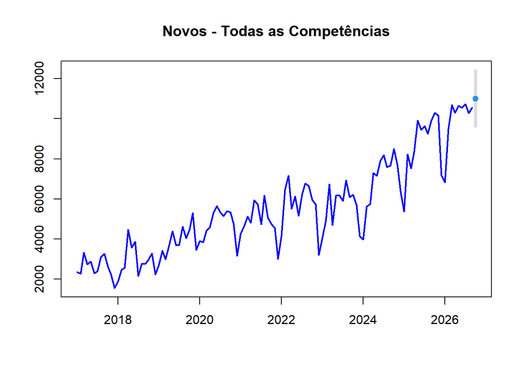

```r
fit_NOVOS_mensal %>% forecast (h=1, level=95) %>% plot(main="Novos - Todas as Competências",col="blue",lwd=2)
```

## 6.2 Câmara de Direito Privado

**Série Temporal (Câmara de Direito Privado)**

```r
NOVOS=Produtividade[(Produtividade$"INDICADOR" == "Novos"),]
NOVOS_Camara_DP=NOVOS[(NOVOS$COMPETÊNCIA == "Câmara de Direito Privado"),]
NOVOS_Camara_DP=aggregate(cbind(NOVOS_Camara_DP$Quantidade)~NOVOS_Camara_DP$`N. Mês` + NOVOS_Camara_DP$ANO,data=NOVOS_Camara_DP,sum)
NOVOS_Camara_DP_mensal=data.frame(NOVOS_Camara_DP)
NOVOS_Camara_DP_mensal=data.frame(NOVOS_Camara_DP_mensal[,3])
NOVOS_Camara_DP_mensal_st=ts(NOVOS_Camara_DP_mensal, start=c(2017,1),frequency = 12);NOVOS_Camara_DP_mensal_st
```

```
##       Jan  Feb  Mar  Apr  May  Jun  Jul  Aug  Sep  Oct  Nov  Dec
## 2017  943  883 1636 1339 1283  881 1084 1411 1428 1136  916  597
## 2018  636 1143 1204 1829 1424 1466  754 1064 1090 1156 1316  884
## 2019 1165 1520 1533 1786 2120 1709 1588 2216 2053 2102 2717 1573
## 2020 1706 1709 1889 1760 1965 2415 2436 2240 2387 2102 1970 1268
## 2021 1763 1989 2187 2096 2530 2610 2102 2854 2148 2221 2091 1293
## 2022 1714 2997 3451 2573 2711 2183 2956 2905 3009 2861 2690 1518
## 2023 2008 2741 3588 2609 3265 3407 3333 4107 3306 3485 3008 2125
## 2024 2025 3127 3141 4071 3859 4254 4584 4446 4332 4876 3935 3260
## 2025 2661 4354 3785 4476 5285 3828 5193 5333 5672 5914 5552 3850
## 2026 3688 5569 6034 5937 5795 6177 6099 5810 5342
```

**Modelo ajustado (Câmara de Direito Privado)**

```r
fit_NOVOS_Camara_DP_mensal = auto.arima(NOVOS_Camara_DP_mensal_st)
fit_NOVOS_Camara_DP_mensal = fit_NOVOS_Camara_DP_mensal %>% forecast (h=1, level=95)
fit_NOVOS_Camara_DP_mensal
```

```
##          Point Forecast    Lo 95    Hi 95
## Oct 2026       6045.348 5160.291 6930.404
```

**Estimativa pontual da quantidade de Novos (Câmara de Direito Privado)**

```r
NOVOS_Camara_DP_media=round(fit_NOVOS_Camara_DP_mensal$mean,0)
NOVOS_Camara_DP_media
```

```
##       Oct
## 2026 6045
```

**Limite Inferior do intervalo de confiança da quantidade de Novos (Câmara de Direito Privado)**

```r
NOVOS_Camara_DP_inferior=round(fit_NOVOS_Camara_DP_mensal$lower,0)
NOVOS_Camara_DP_inferior
```

```
##       Oct
## 2026 5160
```

**Limite Superior do intervalo de confiança da quantidade de Novos (Câmara de Direito Privado)**

```r
NOVOS_Camara_DP_superior=round(fit_NOVOS_Camara_DP_mensal$upper,0)
NOVOS_Camara_DP_superior
```

```
##       Oct
## 2026 6930
```

**Gráfico da série temporal com a estimativa pontual e intervalo de confiança com 95% de confiança (Câmara de Direito Privado)**

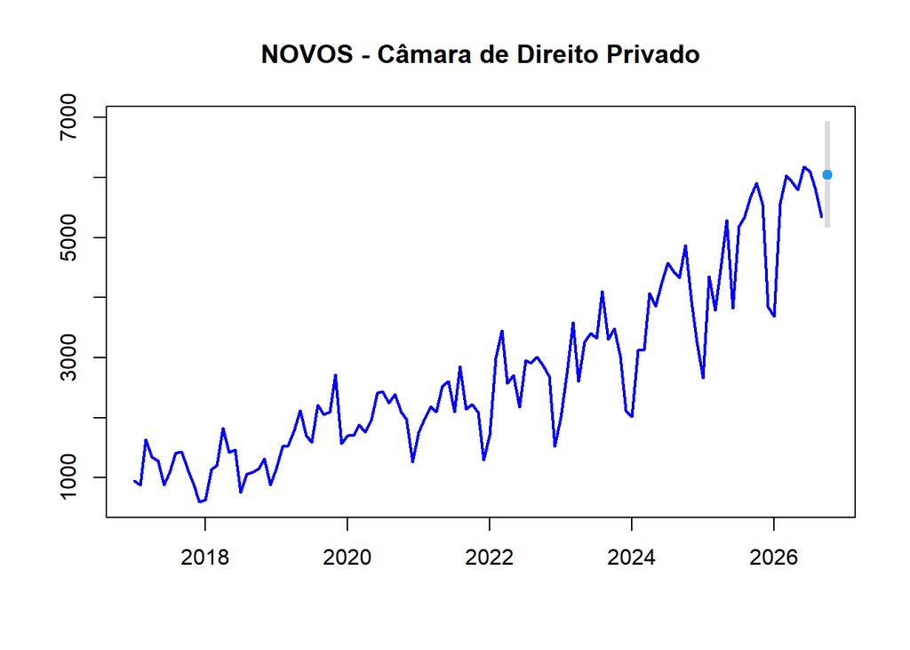

```r
fit_NOVOS_Camara_DP_mensal %>% forecast (h=1, level=95) %>% plot(main="NOVOS - Câmara de Direito Privado",col="blue",lwd=2)
```

## 6.3 Câmara de Direito Público

**Série Temporal (Câmara de Direito Público)**

```r
NOVOS=Produtividade[(Produtividade$"INDICADOR" == "Novos"),]
NOVOS_Camara_DPU=NOVOS[(NOVOS$COMPETÊNCIA == "Câmara de Direito Público"),]
NOVOS_Camara_DPU=aggregate(cbind(NOVOS_Camara_DPU$Quantidade)~NOVOS_Camara_DPU$`N. Mês` + NOVOS_Camara_DPU$ANO,data=NOVOS_Camara_DPU,sum)
NOVOS_Camara_DPU_mensal=data.frame(NOVOS_Camara_DPU)
NOVOS_Camara_DPU_mensal=data.frame(NOVOS_Camara_DPU_mensal[,3])
NOVOS_Camara_DPU_mensal_st=ts(NOVOS_Camara_DPU_mensal, start=c(2017,1),frequency = 12);NOVOS_Camara_DPU_mensal_st
```

```
##       Jan  Feb  Mar  Apr  May  Jun  Jul  Aug  Sep  Oct  Nov  Dec
## 2017  722  666  812  597  646  515  501  767  734  632  521  403
## 2018  476  575  495 1153 1106 1281  532  755  740  778  883  660
## 2019  626  821  671  822  982  870  804 1127  989 1046 1299 1020
## 2020 1134 1155 1140 1168 1384 1173 1221 1418 1586 1750 1204  810
## 2021 1081 1139 1468 1356 1691 1637 1281 1830 1480 1205 1001  802
## 2022 1095 2019 2224 1603 1771 1352 1994 2021 1799 1658 1325  869
## 2023  748  932 1439  902 1135 1113  987 1142 1015 1079 1063  874
## 2024  591 1015 1198 1415 1505 1687 1669 1332 1306 1567 1927 1486
## 2025 1116 1821 2075 1968 2451 2443 2407 1951 2010 2182 2372 1614
## 2026 1280 1908 2437 2151 2663 2671 2453 2158 2213
```

**Modelo ajustado (Câmara de Direito Público)**

```r
fit_NOVOS_Camara_DPU_mensal = auto.arima(NOVOS_Camara_DPU_mensal_st)
fit_NOVOS_Camara_DPU_mensal = fit_NOVOS_Camara_DPU_mensal %>% forecast (h=1, level=95)
fit_NOVOS_Camara_DPU_mensal
```

```
##          Point Forecast    Lo 95    Hi 95
## Oct 2026        2337.28 1838.627 2835.934
```

**Estimativa pontual da quantidade de Novos (Câmara de Direito Público)**

```r
NOVOS_Camara_DPU_media=round(fit_NOVOS_Camara_DPU_mensal$mean,0)
NOVOS_Camara_DPU_media
```

```
##       Oct
## 2026 2337
```

**Limite Inferior do intervalo de confiança da quantidade de Novos (Câmara de Direito Público)**

```r
NOVOS_Camara_DPU_inferior=round(fit_NOVOS_Camara_DPU_mensal$lower,0)
NOVOS_Camara_DPU_inferior
```

```
##       Oct
## 2026 1839
```

**Limite Superior do intervalo de confiança da quantidade de Novos (Câmara de Direito Público)**

```r
NOVOS_Camara_DPU_superior=round(fit_NOVOS_Camara_DPU_mensal$upper,0)
NOVOS_Camara_DPU_superior
```

```
##       Oct
## 2026 2836
```

**Gráfico da série temporal com a estimativa pontual e intervalo de confiança com 95% de confiança (Câmara de Direito Público)**

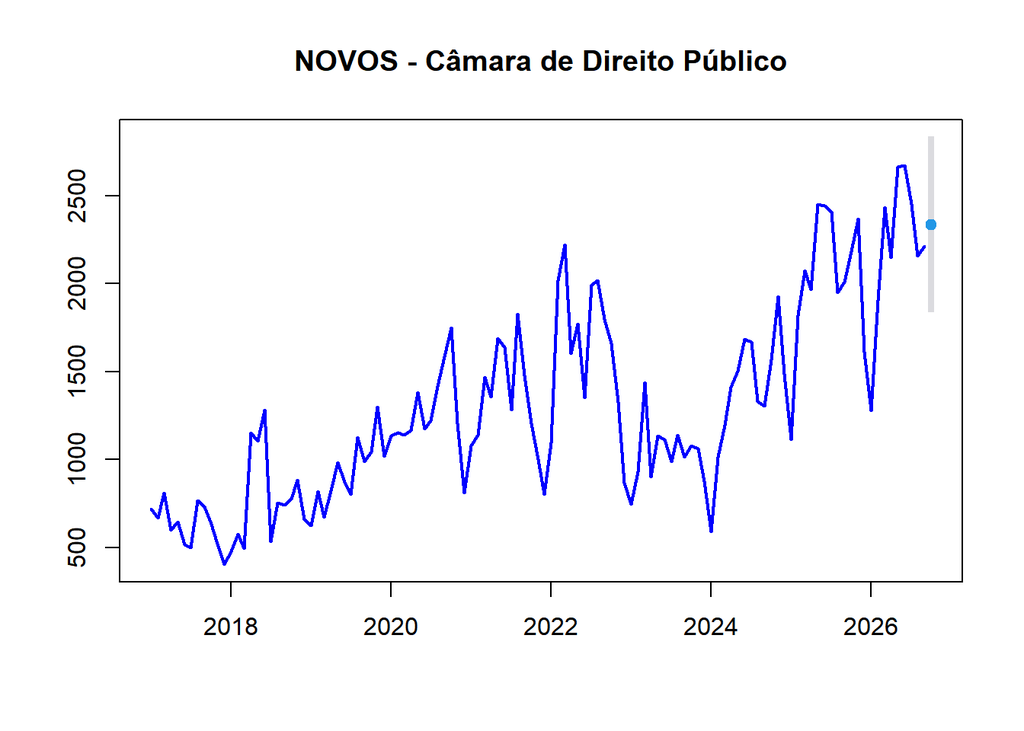

```r
fit_NOVOS_Camara_DPU_mensal %>% forecast (h=1, level=95) %>% plot(main="NOVOS - Câmara de Direito Público",col="blue",lwd=2)
```

## 6.4 Órgão Especial

**Série Temporal (Órgão Especial)**

```r
NOVOS=Produtividade[(Produtividade$"INDICADOR" == "Novos"),]
NOVOS_Orgao_Especial=NOVOS[(NOVOS$COMPETÊNCIA == "Órgão Especial"),]
NOVOS_Orgao_Especial=aggregate(cbind(NOVOS_Orgao_Especial$Quantidade)~NOVOS_Orgao_Especial$`N. Mês` + NOVOS_Orgao_Especial$ANO,data=NOVOS_Orgao_Especial,sum)
NOVOS_Orgao_Especial_mensal=data.frame(NOVOS_Orgao_Especial)
NOVOS_Orgao_Especial_mensal=data.frame(NOVOS_Orgao_Especial_mensal[,3])
NOVOS_Orgao_Especial_mensal_st=ts(NOVOS_Orgao_Especial_mensal, start=c(2017,1),frequency = 12);NOVOS_Orgao_Especial_mensal_st
```

```
##      Jan Feb Mar Apr May Jun Jul Aug Sep Oct Nov Dec
## 2017  59  63  47  31  32  45  47  40  33  29  32  31
## 2018  52  48  36  43  42  37  40  49  58  56  31  16
## 2019  19  30  29  49  43  52  46  51  38  51  30  32
## 2020  30  33  51  59  87  48  52  39  30  68 283 199
## 2021 145  91  72  52  44  46  35  44  45  36  45  40
## 2022  92  71  87  68  89  40  58  48  42  33  44  12
## 2023  23  21  36  33  29  41  61  45  65  80  52  30
## 2024  31  40  53  56  58  72  72  69  61  60  76  51
## 2025  65  95  58  67  57  45  50  74  87  94  95  62
## 2026  76  90  98  83  78 117 130  94 145
```

**Modelo ajustado (Órgão Especial)**

```r
fit_NOVOS_Orgao_Especial_mensal = auto.arima(NOVOS_Orgao_Especial_mensal_st)
fit_NOVOS_Orgao_Especial_mensal = fit_NOVOS_Orgao_Especial_mensal %>% forecast (h=1, level=95)
fit_NOVOS_Orgao_Especial_mensal
```

```
##          Point Forecast    Lo 95   Hi 95
## Oct 2026            145 89.64395 200.356
```

**Estimativa pontual da quantidade de Novos (Órgão Especial)**

```r
NOVOS_Orgao_Especial_media=round(fit_NOVOS_Orgao_Especial_mensal$mean,0)
NOVOS_Orgao_Especial_media
```

```
##      Oct
## 2026 145
```

**Limite Inferior do intervalo de confiança da quantidade de Novos (Órgão Especial)**

```r
NOVOS_Orgao_Especial_inferior=round(fit_NOVOS_Orgao_Especial_mensal$lower,0)
NOVOS_Orgao_Especial_inferior
```

```
##      Oct
## 2026  90
```

**Limite Superior do intervalo de confiança da quantidade de Novos (Órgão Especial)**

```r
NOVOS_Orgao_Especial_superior=round(fit_NOVOS_Orgao_Especial_mensal$upper,0)
NOVOS_Orgao_Especial_superior
```

```
##      Oct
## 2026 200
```

**Gráfico da série temporal com a estimativa pontual e intervalo de confiança com 95% de confiança (Órgão Especial)**

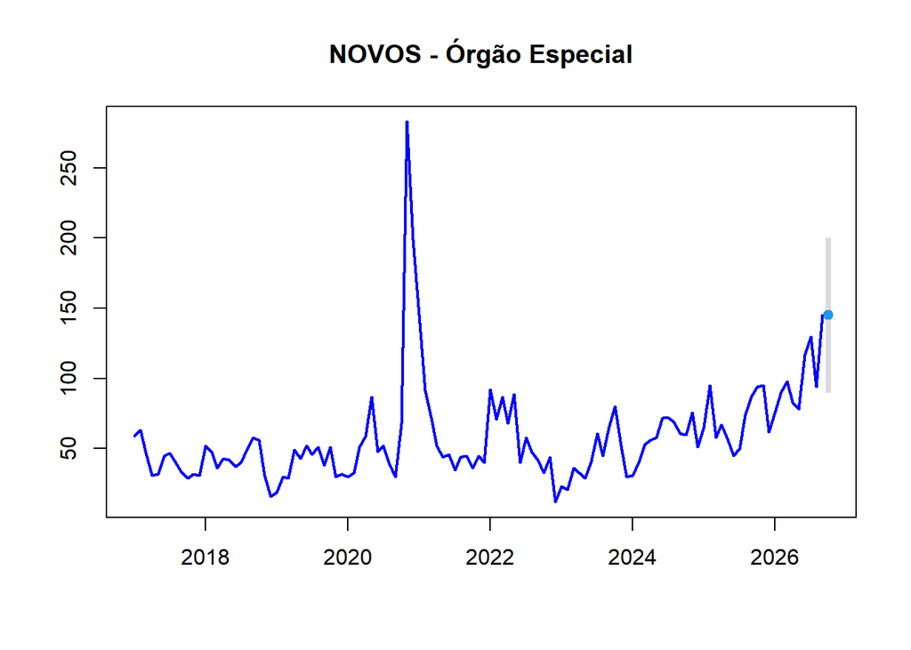

```r
fit_NOVOS_Orgao_Especial_mensal %>% forecast (h=1, level=95) %>% plot(main="NOVOS - Órgão Especial",col="blue",lwd=2)
```

## 6.5 Câmara Criminal

**Série Temporal (Câmara Criminal)**

```r
NOVOS=Produtividade[(Produtividade$"INDICADOR" == "Novos"),]
NOVOS_Camara_Criminal=NOVOS[(NOVOS$COMPETÊNCIA == "Câmara Criminal"),]
NOVOS_Camara_Criminal=aggregate(cbind(NOVOS_Camara_Criminal$Quantidade)~NOVOS_Camara_Criminal$`N. Mês` + NOVOS_Camara_Criminal$ANO,data=NOVOS_Camara_Criminal,sum)
NOVOS_Camara_Criminal_mensal=data.frame(NOVOS_Camara_Criminal)
NOVOS_Camara_Criminal_mensal=data.frame(NOVOS_Camara_Criminal_mensal[,3])
NOVOS_Camara_Criminal_mensal_st=ts(NOVOS_Camara_Criminal_mensal, start=c(2017,1),frequency = 12);NOVOS_Camara_Criminal_mensal_st
```

```
##       Jan  Feb  Mar  Apr  May  Jun  Jul  Aug  Sep  Oct  Nov  Dec
## 2017  599  643  803  757  894  831  737  862 1021  781  733  498
## 2018  685  677  816 1424  933 1039  797  869  839  954 1005  642
## 2019  878 1005  721  977 1165 1030 1235 1194  915 1241 1203  801
## 2020  998  924 1239 1587 1843 1966 1609 1402 1350 1382 1259  862
## 2021 1244 1372 1347 1267 1638 1390 1291 1402 1353 1252 1364  847
## 2022 1241 1320 1334 1223 1507 1537 1158 1731 1765 1357 1593  762
## 2023 1220 1164 1587 1111 1659 1569 1465 1546 1653 1483 1497  895
## 2024 1285 1376 1232 1651 1650 1783 1756 1617 1853 1888 1587 1365
## 2025 1387 1798 1434 1635 1942 1695 1846 1754 1958 1952 2002 1440
## 2026 1649 1783 1935 1915 1888 1384 1769 1974 2056
```

**Modelo ajustado (Câmara Criminal)**

```r
fit_NOVOS_Camara_Criminal_mensal = auto.arima(NOVOS_Camara_Criminal_mensal_st)
fit_NOVOS_Camara_Criminal_mensal = fit_NOVOS_Camara_Criminal_mensal %>% forecast (h=1, level=95)
fit_NOVOS_Camara_Criminal_mensal
```

```
##          Point Forecast    Lo 95    Hi 95
## Oct 2026        1969.79 1562.642 2376.938
```

**Estimativa pontual da quantidade de Novos (Câmara Criminal)**

```r
NOVOS_Camara_Criminal_media=round(fit_NOVOS_Camara_Criminal_mensal$mean,0)
NOVOS_Camara_Criminal_media
```

```
##       Oct
## 2026 1970
```

**Limite Inferior do intervalo de confiança da quantidade de Novos (Câmara Criminal)**

```r
NOVOS_Camara_Criminal_inferior=round(fit_NOVOS_Camara_Criminal_mensal$lower,0)
NOVOS_Camara_Criminal_inferior
```

```
##       Oct
## 2026 1563
```

**Limite Superior do intervalo de confiança da quantidade de Novos (Câmara Criminal)**

```r
NOVOS_Camara_Criminal_superior=round(fit_NOVOS_Camara_Criminal_mensal$upper,0)
NOVOS_Camara_Criminal_superior
```

```
##       Oct
## 2026 2377
```

**Gráfico da série temporal com a estimativa pontual e intervalo de confiança com 95% de confiança (Câmara Criminal)**

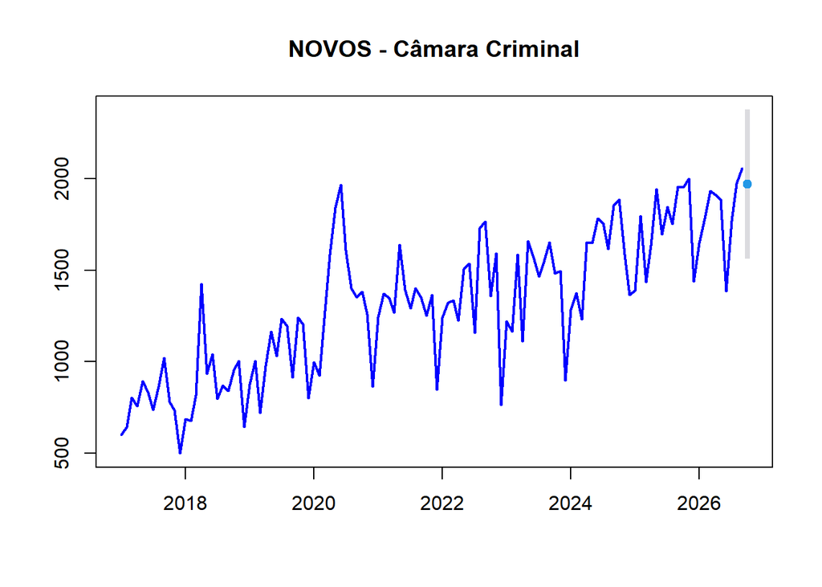

```r
fit_NOVOS_Camara_Criminal_mensal %>% forecast (h=1, level=95) %>% plot(main="NOVOS - Câmara Criminal",col="blue",lwd=2)
```

## 6.6 Demais Competências

**Série Temporal (Demais Competências)**

```r
NOVOS_Demais=Produtividade[(Produtividade$"INDICADOR" == "Novos" & Produtividade$"COMPETÊNCIA" == "Demais"),]
NOVOS_Demais=aggregate(cbind(NOVOS_Demais$Quantidade)~NOVOS_Demais$`N. Mês` + NOVOS_Demais$ANO,data=NOVOS_Demais,sum)
NOVOS_Demais=data.frame(NOVOS_Demais)
NOVOS_Demais=data.frame(NOVOS_Demais[,3])
NOVOS_Demais_st=ts(NOVOS_Demais, start=c(2017,1),frequency = 12);NOVOS_Demais_st
```

```
##       Jan  Feb  Mar  Apr  May  Jun  Jul  Aug  Sep  Oct  Nov  Dec
## 2017   25   14   16   19   27   22   15   27   43   37   32   22
## 2018   29   17   20   20   68   48   38   38   32   37   49   29
## 2019   29   39   41   29   85   34   42   32   44   47   41   25
## 2020   39   29   90   27   26   39   35   44   47   37   46   29
## 2021   30   38   40   46   43   37   29   39   31   36   47   29
## 2022   39   50   70   43   54   48   56   58   46   47   64   43
## 2023   66   53   72   48   78   64   59   79   59   72   59  226
## 2024   45   61  110   99   94   97  104  115  102  114  156  214
## 2025  138  150  172  208  171 1440  139  144  179  166  143  204
## 2026  131  150  180  207  221  200  276  237  800
```

**Modelo ajustado (Demais Competências)**

```r
fit_NOVOS_Demais = auto.arima(NOVOS_Demais_st)
fit_NOVOS_Demais = fit_NOVOS_Demais %>% forecast (h=1, level=95)
fit_NOVOS_Demais
```

```
##          Point Forecast    Lo 95    Hi 95
## Oct 2026       289.1362 21.35152 556.9208
```

**Estimativa pontual da quantidade de Novos (Demais Competências)**

```r
NOVOS_Demais_media=round(fit_NOVOS_Demais$mean,0)
NOVOS_Demais_media
```

```
##      Oct
## 2026 289
```

**Limite Inferior do intervalo de confiança da quantidade de Novos (Demais Competências)**

```r
NOVOS_Demais_inferior=round(fit_NOVOS_Demais$lower,0)
NOVOS_Demais_inferior
```

```
##      Oct
## 2026  21
```

**Limite Superior do intervalo de confiança da quantidade de Novos (Demais Competências)**

```r
NOVOS_Demais_superior=round(fit_NOVOS_Demais$upper,0)
NOVOS_Demais_superior
```

```
##      Oct
## 2026 557
```

**Gráfico da série temporal com a estimativa pontual e intervalo de confiança com 95% de confiança (Demais Competências)**

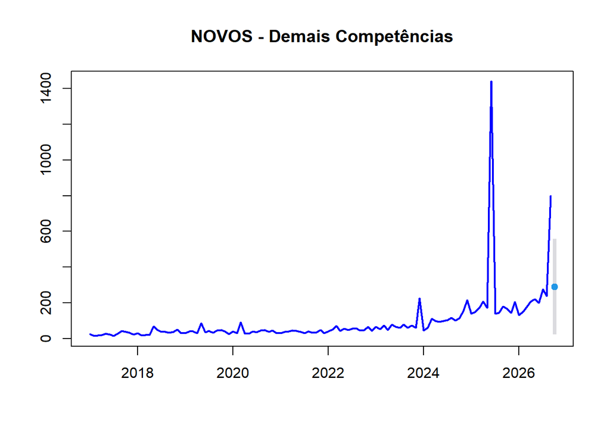

```r
fit_NOVOS_Demais %>% forecast (h=1, level=95) %>% plot(main="NOVOS - Demais Competências",col="blue",lwd=2)
```

## 6.7 Tabela de Previsões

```r
Todos=c(NOVOS_mensal_media,
NOVOS_mensal_inferior,
NOVOS_mensal_superior)

Câmara_de_Direito_Privado=c(NOVOS_Camara_DP_media,
NOVOS_Camara_DP_inferior,
NOVOS_Camara_DP_superior)

Câmara_de_Direito_Público=c(NOVOS_Camara_DPU_media,
NOVOS_Camara_DPU_inferior,
NOVOS_Camara_DPU_superior)

Órgão_Especial=c(NOVOS_Orgao_Especial_media,
NOVOS_Orgao_Especial_inferior,
NOVOS_Orgao_Especial_superior)

Câmara_Criminal=c(NOVOS_Camara_Criminal_media,
NOVOS_Camara_Criminal_inferior,
NOVOS_Camara_Criminal_superior)

Demais=c(NOVOS_Demais_media,
NOVOS_Demais_inferior,
NOVOS_Demais_superior)


Novos=rbind(Todos,Câmara_de_Direito_Privado,Câmara_de_Direito_Público,Órgão_Especial,Câmara_Criminal,Demais)
colnames(Novos) = c("Previsão","Limite Inferior","Limite Superior")
Novos=data.frame(Novos)
Novos
```

```
##                           Previsão Limite.Inferior Limite.Superior
## Todos                        11001            9559           12443
## Câmara_de_Direito_Privado     6045            5160            6930
## Câmara_de_Direito_Público     2337            1839            2836
## Órgão_Especial                 145              90             200
## Câmara_Criminal               1970            1563            2377
## Demais                         289              21             557
```

```r
datatable(Novos,
          editable="cell",
          caption = "Previsões de Novos com intervalo de confiança preditivo de 95% de confiabilidade",
          extensions = "Buttons",
          filter='top',
          options=list(papeLength=10,
                       searching=TRUE,
                       dom='Blfrtip',
                       buttons=c('copy','csv','excel','pdf','print')))
```

|  | Previsão | Limite.Inferior | Limite.Superior |
| --- | --- | --- | --- |
| Todos | 11001 | 9559 | 12443 |
| Câmara_de_Direito_Privado | 6045 | 5160 | 6930 |
| Câmara_de_Direito_Público | 2337 | 1839 | 2836 |
| Órgão_Especial | 145 | 90 | 200 |
| Câmara_Criminal | 1970 | 1563 | 2377 |
| Demais | 289 | 21 | 557 |